# IODS course project

# Doing logistic regression analysis

## 1. The data.

Just for fun and games we will print the summary of the data we are about to use. The summary is somewhat difficult to read, so feel free to skip to the actual work.

Looking at the data:

```
##        X          school   sex          age        address famsize
##  Min.   :  1.00   GP:342   F:198   Min.   :15.00   R: 81   GT3:278
##  1st Qu.: 96.25   MS: 40   M:184   1st Qu.:16.00   U:301   LE3:104
##  Median :191.50                    Median :17.00
##  Mean   :191.50                    Mean   :16.59
##  3rd Qu.:286.75                    3rd Qu.:17.00
##  Max.   :382.00                    Max.   :22.00
##  Pstatus      Medu            Fedu             Mjob           Fjob
##  A: 38   Min.   :0.000   Min.   :0.000   at_home : 53   at_home : 16
##  T:344   1st Qu.:2.000   1st Qu.:2.000   health  : 33   health  : 17
##          Median :3.000   Median :3.000   other   :138   other   :211
##          Mean   :2.806   Mean   :2.565   services: 96   services:107
##          3rd Qu.:4.000   3rd Qu.:4.000   teacher : 62   teacher : 31
##          Max.   :4.000   Max.   :4.000
##         reason    nursery   internet    guardian     traveltime
##  course    :140   no : 72   no : 58   father: 91   Min.   :1.000
##  home      :110   yes:310   yes:324   mother:275   1st Qu.:1.000
##  other     : 34                       other : 16   Median :1.000
##  reputation: 98                                    Mean   :1.448
##                                                    3rd Qu.:2.000
##                                                    Max.   :4.000
##    studytime        failures      schoolsup famsup     paid     activities
##  Min.   :1.000   Min.   :0.0000   no :331   no :144   no :205   no :181
##  1st Qu.:1.000   1st Qu.:0.0000   yes: 51   yes:238   yes:177   yes:201
##  Median :2.000   Median :0.0000
##  Mean   :2.037   Mean   :0.2016
##  3rd Qu.:2.000   3rd Qu.:0.0000
##  Max.   :4.000   Max.   :3.0000
##  higher    romantic      famrel         freetime        goout
##  no : 18   no :261   Min.   :1.000   Min.   :1.00   Min.   :1.000
##  yes:364   yes:121   1st Qu.:4.000   1st Qu.:3.00   1st Qu.:2.000
##                      Median :4.000   Median :3.00   Median :3.000
##                      Mean   :3.937   Mean   :3.22   Mean   :3.113
##                      3rd Qu.:5.000   3rd Qu.:4.00   3rd Qu.:4.000
##                      Max.   :5.000   Max.   :5.00   Max.   :5.000
##       Dalc            Walc           health         absences
##  Min.   :1.000   Min.   :1.000   Min.   :1.000   Min.   : 0.0
##  1st Qu.:1.000   1st Qu.:1.000   1st Qu.:3.000   1st Qu.: 1.0
##  Median :1.000   Median :2.000   Median :4.000   Median : 3.0
##  Mean   :1.482   Mean   :2.296   Mean   :3.573   Mean   : 4.5
##  3rd Qu.:2.000   3rd Qu.:3.000   3rd Qu.:5.000   3rd Qu.: 6.0
##  Max.   :5.000   Max.   :5.000   Max.   :5.000   Max.   :45.0
##        G1              G2              G3           alc_use
##  Min.   : 2.00   Min.   : 4.00   Min.   : 0.00   Min.   :1.000
##  1st Qu.:10.00   1st Qu.:10.00   1st Qu.:10.00   1st Qu.:1.000
##  Median :12.00   Median :12.00   Median :12.00   Median :1.500
##  Mean   :11.49   Mean   :11.47   Mean   :11.46   Mean   :1.889
##  3rd Qu.:14.00   3rd Qu.:14.00   3rd Qu.:14.00   3rd Qu.:2.500
##  Max.   :18.00   Max.   :18.00   Max.   :18.00   Max.   :5.000
##   high_use
##  Mode :logical
##  FALSE:268
##  TRUE :114
##
##
##
```

```
##  [1] "X"          "school"     "sex"        "age"        "address"
##  [6] "famsize"    "Pstatus"    "Medu"       "Fedu"       "Mjob"
## [11] "Fjob"       "reason"     "nursery"    "internet"   "guardian"
## [16] "traveltime" "studytime"  "failures"   "schoolsup"  "famsup"
## [21] "paid"       "activities" "higher"     "romantic"   "famrel"
## [26] "freetime"   "goout"      "Dalc"       "Walc"       "health"
## [31] "absences"   "G1"         "G2"         "G3"         "alc_use"
## [36] "high_use"
```

The data consists of 36 variables and 382 observations. The first column X is only the identification number for the data. The data is gathered from two schools with a questionnaire to students and school reports and wrangled so that only students who studied both mathematics and portuguese are included.

We are interested in the link between alcohol consumption (specifically binary response, high or low) and some other interesting variables. Specifically, we will look at the variables “absences”, “health”, “sex” and “G3”, which means the mean final grade of math and portuguese of the student in question.

The basic assumptions are clear: high alcohol consumption could have an increasing effect on absences, a decreasing effect on health, sex could well have an effect on consumption (either way, but mostly women tend to drink less) and finally, the final grade should sink if one consumes a lot.

## 2. Graphical and numerical analysis

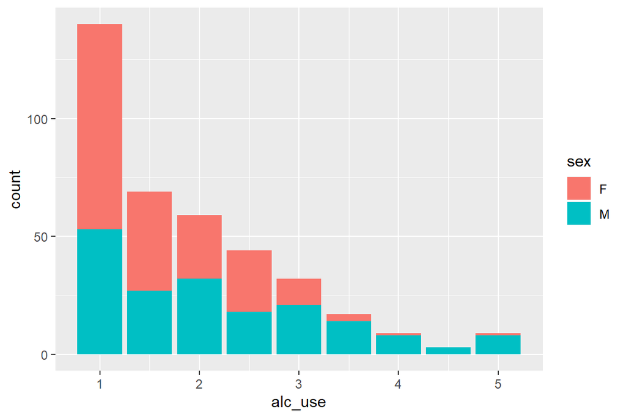

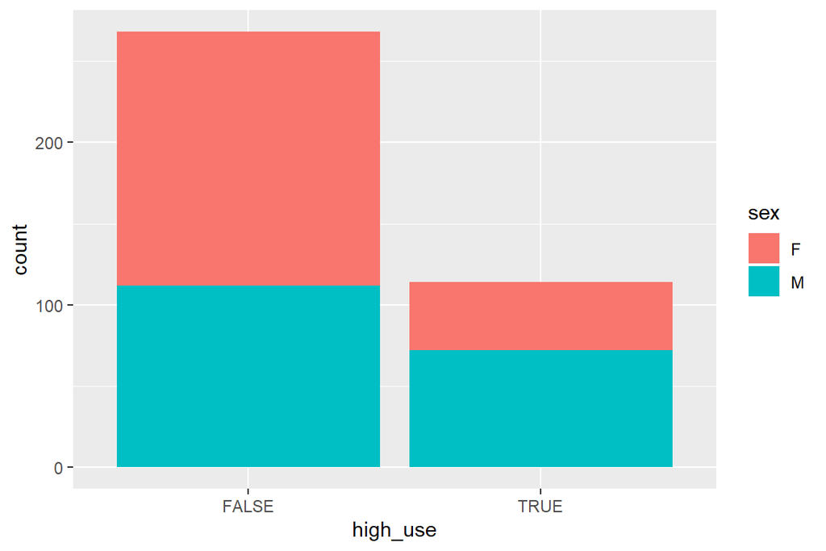

Looking at the distribution of the sex variable, we see what was assumed: women consume slightly less. Now let’s draw a more detailed plot of what’s going on in the variables.

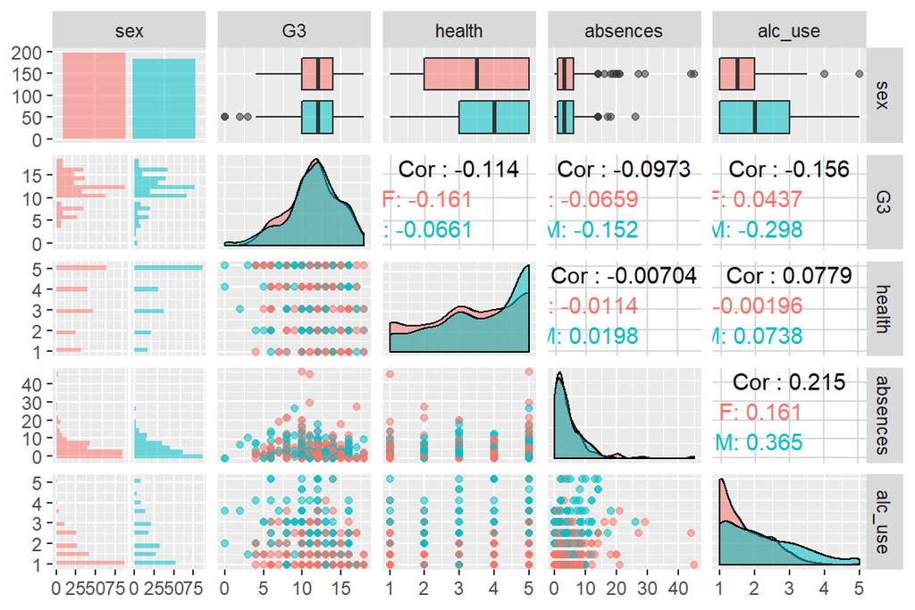

## 3. The logit model

We will now fit a logistic model to the data.

```
##                    OR     2.5 %    97.5 %
## (Intercept) 0.3260597 0.1046920 0.9862794
## G3          0.9284223 0.8648509 0.9957691
## absences    1.0972091 1.0509220 1.1503430
## health      1.0410775 0.8780964 1.2380464
## sexM        2.6365084 1.6462472 4.2800640
```

Here we see the summary of the fitted logistic regression model. The odds ratio for G3 is 0.9 with the confidence interval not overlapping 1 with 95% confidence. This means that odds for high G3 values mean lower odds for alcohol consumption. For absences, the odds ratio is a little over 1, wiht the confidence interval again not containing 1. This means that statistically the higher the absences, the higher the consumption of alcoho. For health we see what previously was seen; the confidence interval contains 1, which means that statistically we cannot be sure if health has any effect, and last but *not least*, the odds ratio for males compared to odds ratio of high alcohol consumption seems to be the highest in this model. This does not mean that sex is the best bet for understanding high alcohol consumption. It only states that the probability of being male seems to give some information on alcohol consumption.

Further analysis is needed if one wants to find out the best fit model for this data.

## 4. The goodness of the model

Looking at our model we decide that since health was not seemingly statistically significant, we leave it out of the model and test the predictive power of the model

$$\begin{equation*}
log(\frac{p}{1-p})=\alpha +\beta_1 x_{G3} +\beta_2 x_{Abs} +\beta_3 x_{Sex} + \epsilon
\end{equation*}$$

Where the coefficients correspond to the normal odds ratio and the odds ratios of G3, Abs and Sex, respectively.

[output not shown]

```
##         prediction
## high_use FALSE TRUE
##    FALSE   256   12
##    TRUE     86   28
```

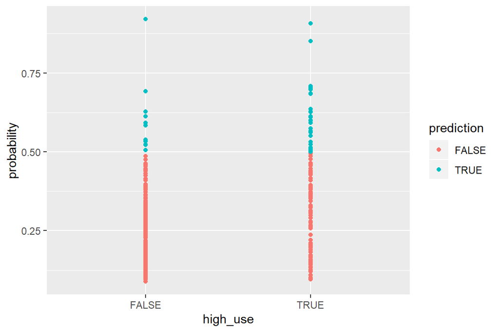

# Week 4 is for classes and fications.

First of all, let’s see the data we’re about to classify and look at it.

## datatataa!

```r
str(Boston)
```

```
## 'data.frame':    506 obs. of  14 variables:
##  $ crim   : num  0.00632 0.02731 0.02729 0.03237 0.06905 ...
##  $ zn     : num  18 0 0 0 0 0 12.5 12.5 12.5 12.5 ...
##  $ indus  : num  2.31 7.07 7.07 2.18 2.18 2.18 7.87 7.87 7.87 7.87 ...
##  $ chas   : int  0 0 0 0 0 0 0 0 0 0 ...
##  $ nox    : num  0.538 0.469 0.469 0.458 0.458 0.458 0.524 0.524 0.524 0.524 ...
##  $ rm     : num  6.58 6.42 7.18 7 7.15 ...
##  $ age    : num  65.2 78.9 61.1 45.8 54.2 58.7 66.6 96.1 100 85.9 ...
##  $ dis    : num  4.09 4.97 4.97 6.06 6.06 ...
##  $ rad    : int  1 2 2 3 3 3 5 5 5 5 ...
##  $ tax    : num  296 242 242 222 222 222 311 311 311 311 ...
##  $ ptratio: num  15.3 17.8 17.8 18.7 18.7 18.7 15.2 15.2 15.2 15.2 ...
##  $ black  : num  397 397 393 395 397 ...
##  $ lstat  : num  4.98 9.14 4.03 2.94 5.33 ...
##  $ medv   : num  24 21.6 34.7 33.4 36.2 28.7 22.9 27.1 16.5 18.9 ...
```

```r
summary(Boston)
```

```
##       crim                zn             indus            chas
##  Min.   : 0.00632   Min.   :  0.00   Min.   : 0.46   Min.   :0.00000
##  1st Qu.: 0.08204   1st Qu.:  0.00   1st Qu.: 5.19   1st Qu.:0.00000
##  Median : 0.25651   Median :  0.00   Median : 9.69   Median :0.00000
##  Mean   : 3.61352   Mean   : 11.36   Mean   :11.14   Mean   :0.06917
##  3rd Qu.: 3.67708   3rd Qu.: 12.50   3rd Qu.:18.10   3rd Qu.:0.00000
##  Max.   :88.97620   Max.   :100.00   Max.   :27.74   Max.   :1.00000
##       nox               rm             age              dis
##  Min.   :0.3850   Min.   :3.561   Min.   :  2.90   Min.   : 1.130
##  1st Qu.:0.4490   1st Qu.:5.886   1st Qu.: 45.02   1st Qu.: 2.100
##  Median :0.5380   Median :6.208   Median : 77.50   Median : 3.207
##  Mean   :0.5547   Mean   :6.285   Mean   : 68.57   Mean   : 3.795
##  3rd Qu.:0.6240   3rd Qu.:6.623   3rd Qu.: 94.08   3rd Qu.: 5.188
##  Max.   :0.8710   Max.   :8.780   Max.   :100.00   Max.   :12.127
##       rad              tax           ptratio          black
##  Min.   : 1.000   Min.   :187.0   Min.   :12.60   Min.   :  0.32
##  1st Qu.: 4.000   1st Qu.:279.0   1st Qu.:17.40   1st Qu.:375.38
##  Median : 5.000   Median :330.0   Median :19.05   Median :391.44
##  Mean   : 9.549   Mean   :408.2   Mean   :18.46   Mean   :356.67
##  3rd Qu.:24.000   3rd Qu.:666.0   3rd Qu.:20.20   3rd Qu.:396.23
##  Max.   :24.000   Max.   :711.0   Max.   :22.00   Max.   :396.90
##      lstat            medv
##  Min.   : 1.73   Min.   : 5.00
##  1st Qu.: 6.95   1st Qu.:17.02
##  Median :11.36   Median :21.20
##  Mean   :12.65   Mean   :22.53
##  3rd Qu.:16.95   3rd Qu.:25.00
##  Max.   :37.97   Max.   :50.00
```

The data looks to be numeric, with some integer variables (chas and rad). The data is on residential areas in the Boston area, with the main application of the data being to explore some aspects of home ownership or living in Boston. The variable chas is 1 if the home is close to the river, 0 otherwise and the variable rad is related to the accessibility to highways, with values ranging from 1 to 24.

### Plots

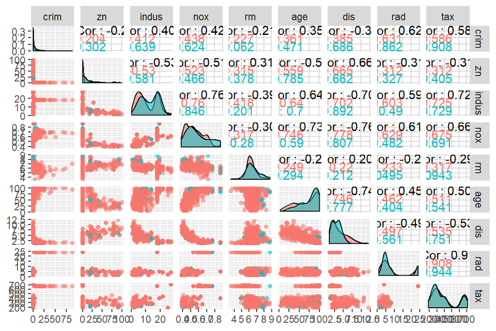

```r
library(MASS)
library(ggplot2)
library(GGally)
library(dplyr)
ggpairs(Boston, columns=c(1,2,3,5,6,7,8,9,10), mapping = aes(col=as.factor(Boston$chas), alpha=0.3), lower = list(combo = wrap("facethist", bins = 20)))
```

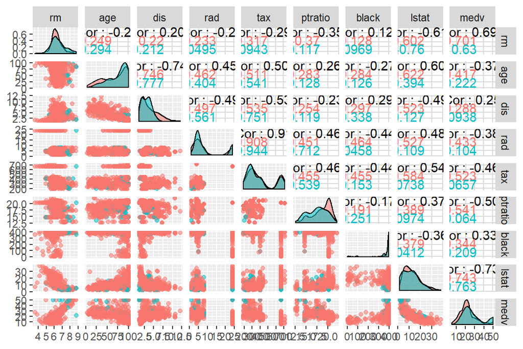

```r
ggpairs(Boston[6:14], mapping = aes(col=as.factor(Boston$chas), alpha=0.3), lower = list(combo = wrap("facethist", bins = 20)))
```

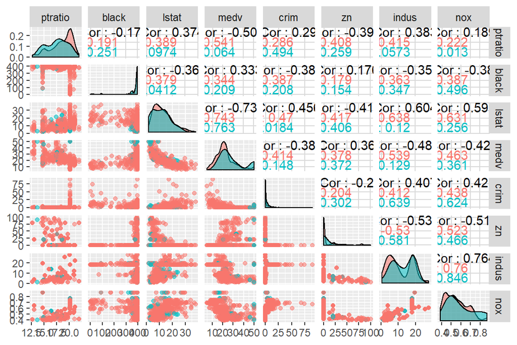

```r
ggpairs(Boston[c(11,12,13,14,1,2,3,5)], mapping = aes(col=as.factor(Boston$chas), alpha=0.3), lower = list(combo = wrap("facethist", bins = 20)))
```

Looking at the distributions of the variables it seems quite clear that the data is not normally distributed. The peakiness of several of the variables, not to mention the obvious skewedness.

The correlations are high for some of the variables, above 0,7 for

nox and the set indus, age and dis  
dis and age  
tax and rad  
istat and medv

This means to say that these variables are likely to have an effect when we do the LDA if we get to it.

But first we have to standardize the data. This means we scale it so that all of it has mean 0 and standard deviation 1:

```
##       crim                 zn               indus
##  Min.   :-0.419367   Min.   :-0.48724   Min.   :-1.5563
##  1st Qu.:-0.410563   1st Qu.:-0.48724   1st Qu.:-0.8668
##  Median :-0.390280   Median :-0.48724   Median :-0.2109
##  Mean   : 0.000000   Mean   : 0.00000   Mean   : 0.0000
##  3rd Qu.: 0.007389   3rd Qu.: 0.04872   3rd Qu.: 1.0150
##  Max.   : 9.924110   Max.   : 3.80047   Max.   : 2.4202
##       chas              nox                rm               age
##  Min.   :-0.2723   Min.   :-1.4644   Min.   :-3.8764   Min.   :-2.3331
##  1st Qu.:-0.2723   1st Qu.:-0.9121   1st Qu.:-0.5681   1st Qu.:-0.8366
##  Median :-0.2723   Median :-0.1441   Median :-0.1084   Median : 0.3171
##  Mean   : 0.0000   Mean   : 0.0000   Mean   : 0.0000   Mean   : 0.0000
##  3rd Qu.:-0.2723   3rd Qu.: 0.5981   3rd Qu.: 0.4823   3rd Qu.: 0.9059
##  Max.   : 3.6648   Max.   : 2.7296   Max.   : 3.5515   Max.   : 1.1164
##       dis               rad               tax             ptratio
##  Min.   :-1.2658   Min.   :-0.9819   Min.   :-1.3127   Min.   :-2.7047
##  1st Qu.:-0.8049   1st Qu.:-0.6373   1st Qu.:-0.7668   1st Qu.:-0.4876
##  Median :-0.2790   Median :-0.5225   Median :-0.4642   Median : 0.2746
##  Mean   : 0.0000   Mean   : 0.0000   Mean   : 0.0000   Mean   : 0.0000
##  3rd Qu.: 0.6617   3rd Qu.: 1.6596   3rd Qu.: 1.5294   3rd Qu.: 0.8058
##  Max.   : 3.9566   Max.   : 1.6596   Max.   : 1.7964   Max.   : 1.6372
##      black             lstat              medv
##  Min.   :-3.9033   Min.   :-1.5296   Min.   :-1.9063
##  1st Qu.: 0.2049   1st Qu.:-0.7986   1st Qu.:-0.5989
##  Median : 0.3808   Median :-0.1811   Median :-0.1449
##  Mean   : 0.0000   Mean   : 0.0000   Mean   : 0.0000
##  3rd Qu.: 0.4332   3rd Qu.: 0.6024   3rd Qu.: 0.2683
##  Max.   : 0.4406   Max.   : 3.5453   Max.   : 2.9865
```

The obvious thing to change is the mean, but let’s look at graphical representations of a couple of variables, namely nox, age and indus:

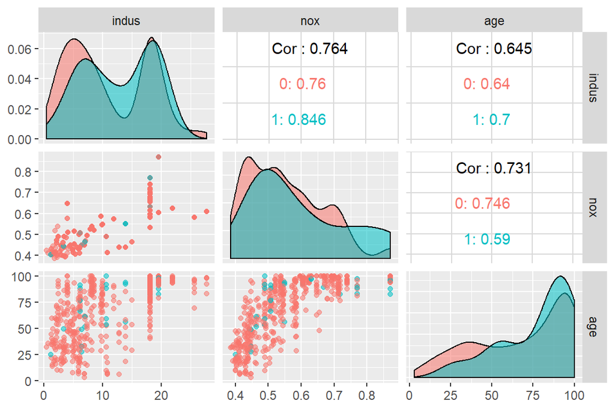

```r
library(MASS)
library(ggplot2)
library(GGally)
library(dplyr)

ggpairs(Boston, columns=c(3,5,7), mapping = aes(col=as.factor(Boston$chas), alpha=0.3), lower = list(combo = wrap("facethist", bins = 20)))
```

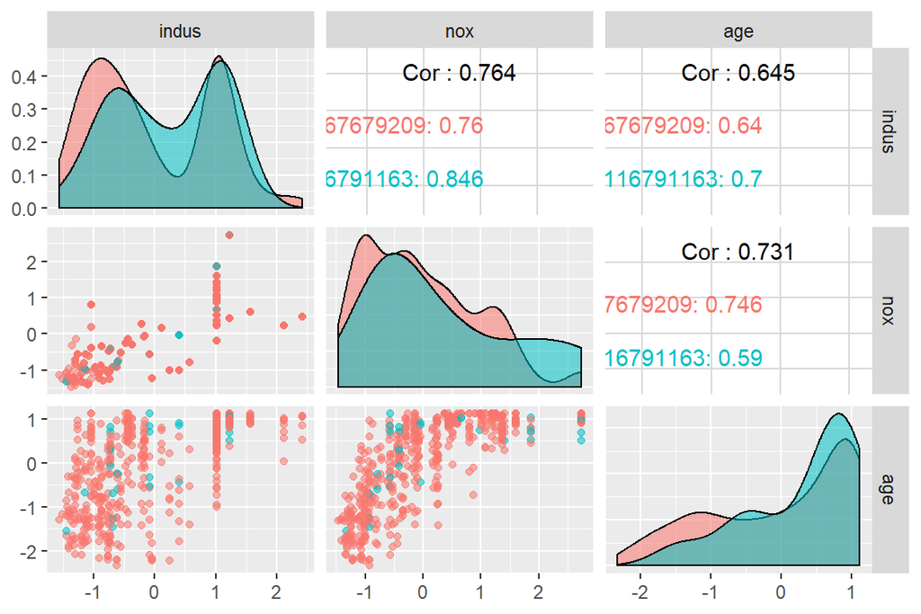

```r
ggpairs(bostondata, columns=c(3,5,7), mapping = aes(col=as.factor(bostondata$chas), alpha=0.3), lower = list(combo = wrap("facethist", bins = 20)))
```

From this representation the difference is clear: the mean becomes 0, but the shape of the distribution is unchanged. Now our data is initialized and we can LDA it. As a final exercise we’ll make a categorical crimerate variable and divide the data into test and train sets (no toy trains, though).

```r
library(MASS)
library(ggplot2)
library(GGally)
library(dplyr)
bostondata<-as.data.frame(scale(Boston))
bins <- quantile(bostondata$crim)
crime <- cut(bostondata$crim, breaks = bins,label=c("low","med_low","med_high","high"), include.lowest = TRUE)
bostondata <- dplyr::select(bostondata, -crim)
bostondata <- data.frame(bostondata, crime)
n <- nrow(bostondata)

ind <- sample(n,  size = n * 0.8)
train <- bostondata[ind,]
test <- bostondata[-ind,]
correct_classes <- test$crime
test <- dplyr::select(test, -crime)
```

## Linear Discriminant Analysis

Lets do **LDA**!

```r
library(MASS)
library(ggplot2)
library(GGally)
library(dplyr)
bostondata<-as.data.frame(scale(Boston))
bins <- quantile(bostondata$crim)
crime <- cut(bostondata$crim, breaks = bins,label=c("low","med_low","med_high","high"), include.lowest = TRUE)
bostondata <- dplyr::select(bostondata, -crim)
bostondata <- data.frame(bostondata, crime)
n <- nrow(bostondata)

ind <- sample(n,  size = n * 0.8)
train <- bostondata[ind,]
test <- bostondata[-ind,]
correct_classes <- test$crime
test <- dplyr::select(test, -crime)
# linear discriminant analysis
lda.fit <- lda(crime~., data = train)

# print the lda.fit object
lda.fit
```

```
## Call:
## lda(crime ~ ., data = train)
##
## Prior probabilities of groups:
##       low   med_low  med_high      high
## 0.2450495 0.2400990 0.2648515 0.2500000
##
## Group means:
##                   zn      indus        chas        nox          rm
## low       1.01930647 -0.9116666 -0.07348562 -0.8920859  0.41524684
## med_low  -0.04564988 -0.2982888 -0.02879709 -0.5798437 -0.14039609
## med_high -0.42312484  0.2369223  0.16921488  0.4061347  0.03626123
## high     -0.48724019  1.0149946 -0.03844192  1.0757160 -0.43552969
##                 age        dis        rad        tax     ptratio
## low      -0.9104609  0.9608821 -0.7022949 -0.7367306 -0.43716698
## med_low  -0.3784978  0.3895116 -0.5449801 -0.5138214 -0.09231802
## med_high  0.4360614 -0.3858625 -0.4022710 -0.2802220 -0.14911383
## high      0.8392915 -0.8751997  1.6596029  1.5294129  0.80577843
##                black      lstat         medv
## low       0.37138744 -0.7498861  0.502411301
## med_low   0.34126748 -0.1326828  0.002149698
## med_high  0.08320565  0.0927926  0.093578545
## high     -0.81932181  0.8585553 -0.658529972
##
## Coefficients of linear discriminants:
##                 LD1          LD2         LD3
## zn       0.13822026  0.589389435 -0.92055804
## indus   -0.08097203 -0.116851329  0.51242985
## chas    -0.05959280 -0.029554022  0.07124885
## nox      0.30550981 -0.817829099 -1.38734925
## rm      -0.11568266 -0.132783491 -0.20237483
## age      0.33108106 -0.303744133 -0.19223294
## dis     -0.17252122 -0.094621022  0.12212862
## rad      3.16860821  1.058546989  0.28034935
## tax      0.03765366 -0.029688105  0.15969387
## ptratio  0.18824045 -0.143470884 -0.38628354
## black   -0.17912007 -0.003276259  0.15695815
## lstat    0.16576701 -0.243734312  0.30429194
## medv     0.16801387 -0.373526530 -0.24084707
##
## Proportion of trace:
##    LD1    LD2    LD3
## 0.9486 0.0403 0.0112
```

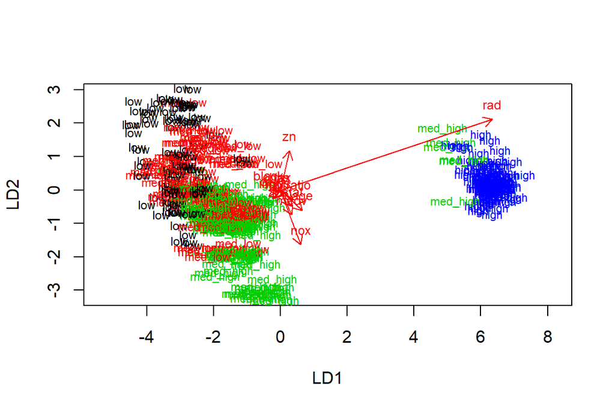

```r
# the function for lda biplot arrows
lda.arrows <- function(x, myscale = 1, arrow_heads = 0.1, color = "red", tex = 0.75, choices = c(1,2)){
  heads <- coef(x)
  arrows(x0 = 0, y0 = 0,
         x1 = myscale * heads[,choices[1]],
         y1 = myscale * heads[,choices[2]], col=color, length = arrow_heads)
  text(myscale * heads[,choices], labels = row.names(heads),
       cex = tex, col=color, pos=3)
}

# target classes as numeric
classes <- as.numeric(train$crime)

# plot the lda results
plot(lda.fit, dimen = 2, col=classes, pch=classes)
lda.arrows(lda.fit, myscale = 2)
```

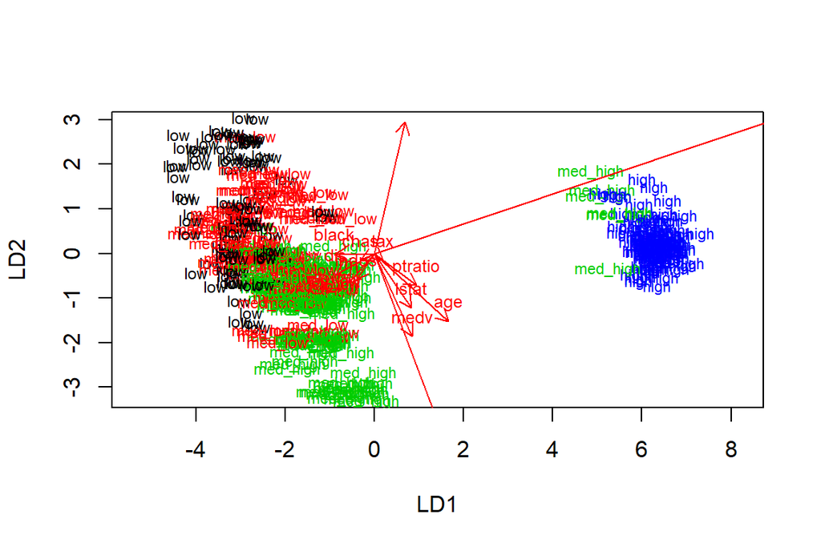

```r
plot(lda.fit, dimen = 2, col=classes, pch=classes)
lda.arrows(lda.fit, myscale = 5)
```

Nice plots. The second one is there so we can actually read the other variables than rad, nox and zn. . .Let me remark that it’s quite dubious to do LDA on a set with a binary variable as it’s sure not to be Gaussian, but let’s not get into that for now. Now lets’s test the model for predictions.

From the plot we see that the variale rad seems to be a high predictor for crime rate. Also, as noted the high correlations of nox and age seem to pop up a bit, though they don’t seem to be very highly associated with crime.

## Predictions

Let’s now predict thigs based on our model.

```r
library(MASS)
library(ggplot2)
library(GGally)
library(dplyr)
library(knitr)
# predict classes with test data
lda.pred <- predict(lda.fit, newdata = test)

# cross tabulate the results
table(correct = correct_classes, predicted = lda.pred$class)
```

```
##           predicted
## correct    low med_low med_high high
##   low       15       9        4    0
##   med_low    2      17       10    0
##   med_high   1       4       14    0
##   high       0       0        1   25
```

## Klustering with Kmeans

Now for some interesting stuff. Let’s see if we get clusters formed.

```r
library(MASS)
library(ggplot2)
library(GGally)
library(dplyr)
boston<-as.data.frame(scale(Boston))

#Let's see the distances of the variables.
dist_eu <- dist(boston)

# look at the summary of the distances
summary(dist_eu)
```

```
##    Min. 1st Qu.  Median    Mean 3rd Qu.    Max.
##  0.1343  3.4625  4.8241  4.9111  6.1863 14.3970
```

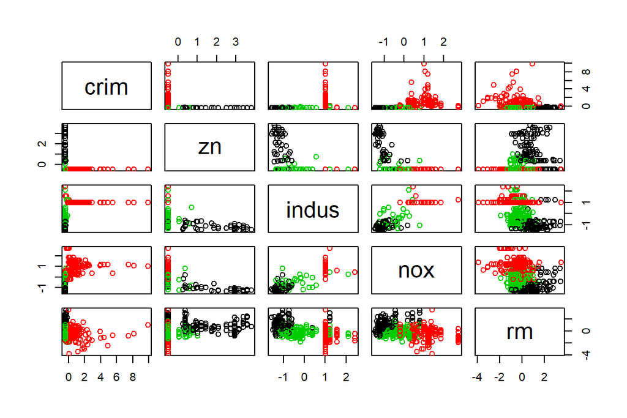

```r
km <-kmeans(boston, centers = 3)

# plot the Boston dataset with clusters
par(mfrow=c(2,2))
pairs(boston[c(1,2,3,5,6)], col = km$cluster)
```

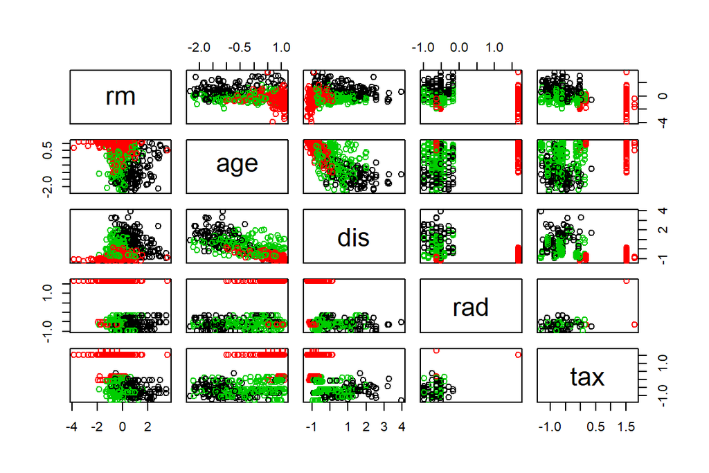

```r
pairs(boston[6:10], col = km$cluster)
```

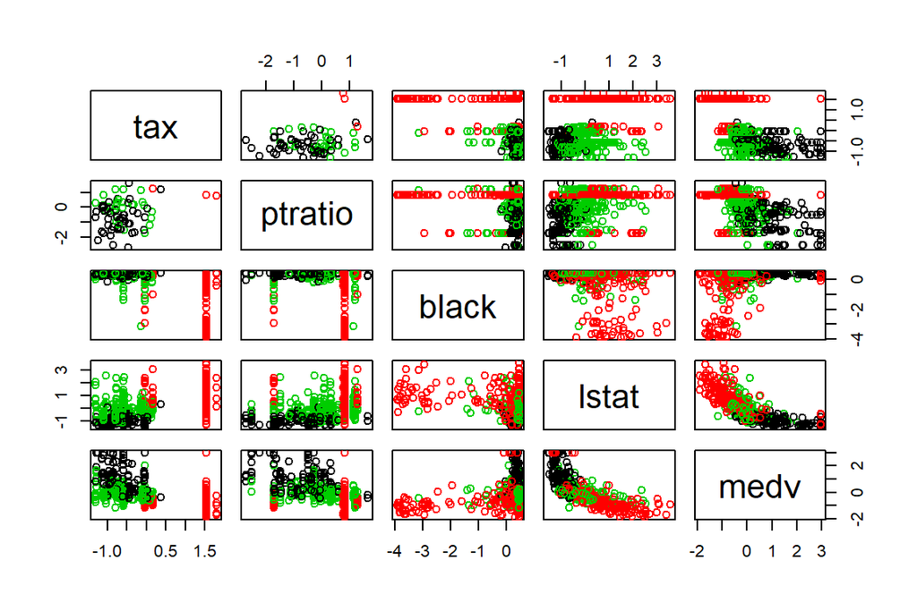

```r
pairs(boston[10:14], col = km$cluster)
```

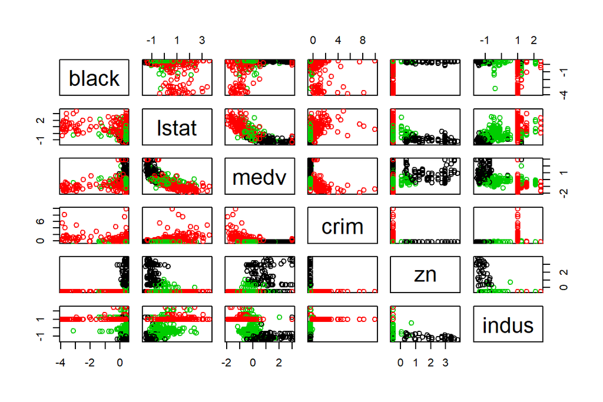

```r
pairs(boston[c(12,13,14,1,2,3)], col = km$cluster)
```

```r
# MASS, ggplot2 and Boston dataset are available
```

We don’t see much with this, but seems that some of the variables have been clustered together by the algorithm.

Now we do the same with clusters (5 is just too much, in my expert opinion and looking at the graph below ).

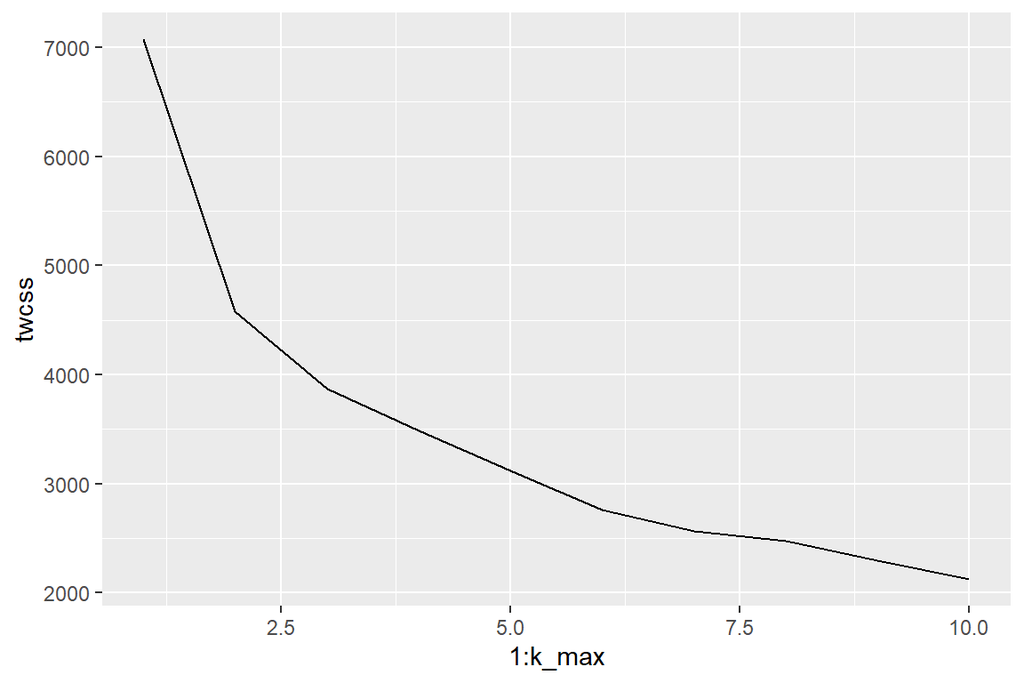

```r
library(MASS)
library(ggplot2)
library(GGally)
library(dplyr)
k_max <- 10

# calculate the total within sum of squares
twcss <- sapply(1:k_max, function(k){kmeans(boston, k)$tot.withinss})

# visualize the results
qplot(x = 1:k_max, y = twcss, geom = 'line')
```

From the plot we see the behaviour of the within clusters sum of squares. As the number of clusters climbs, the sum will sink but we’re not looking for a minimum but for a good change, which happens here at 2 clusters (or 4 clusters, depending on the reader.) We’ll do the clustering again with 2 clusters:

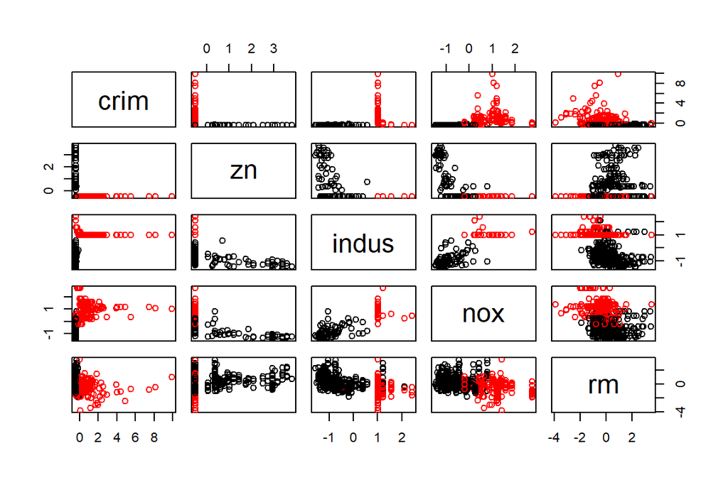

```r
library(MASS)
library(ggplot2)
library(GGally)
library(dplyr)
# k-means clustering
km <-kmeans(boston, centers = 2)

# plot the Boston dataset with clusters
par(mfrow=c(2,2))
pairs(boston[c(1,2,3,5,6)], col = km$cluster)
```

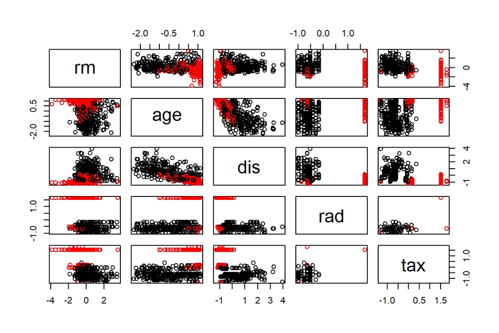

```r
pairs(boston[6:10], col = km$cluster)
```

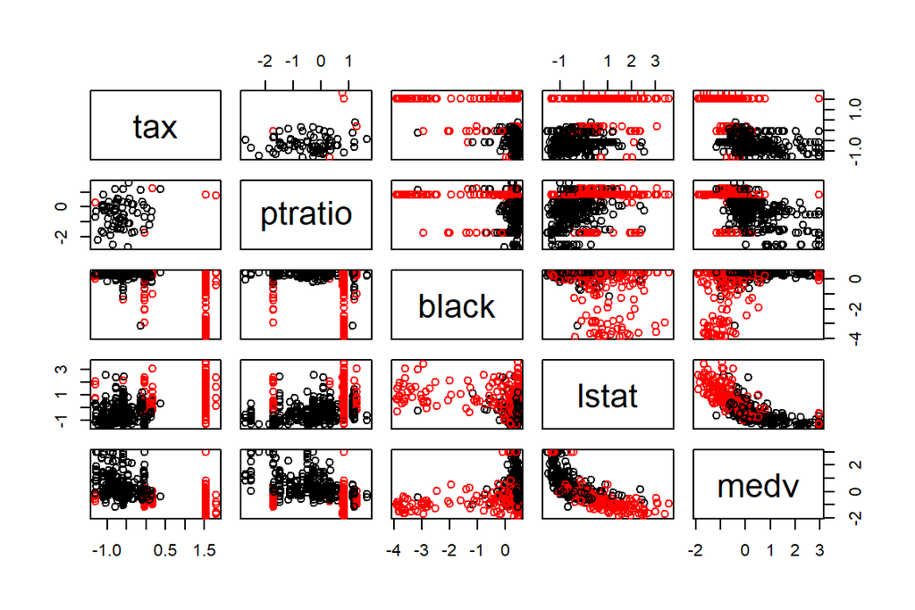

```r
pairs(boston[10:14], col = km$cluster)
```

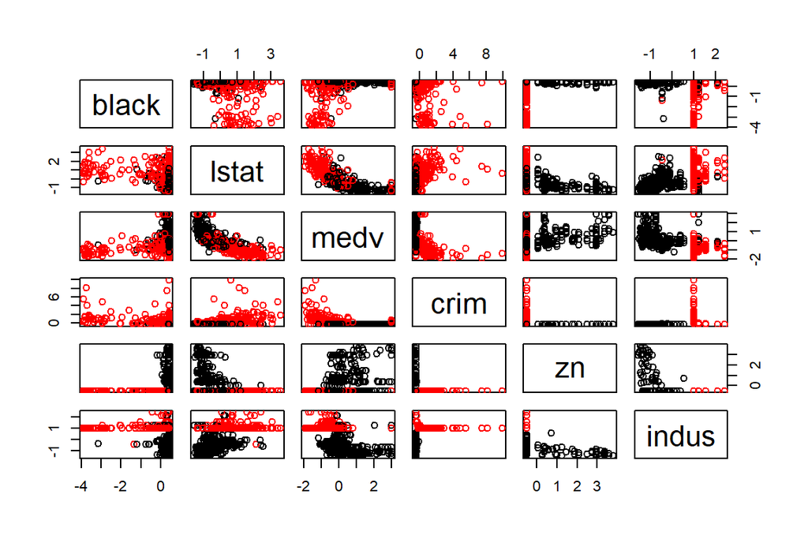

```r
pairs(boston[c(12,13,14,1,2,3)], col = km$cluster)
```

The interpretation is not quite clear. We see from the data that now everything seems to be well clustered, but it still might be more informative if we apply 4 clusters. Lets.

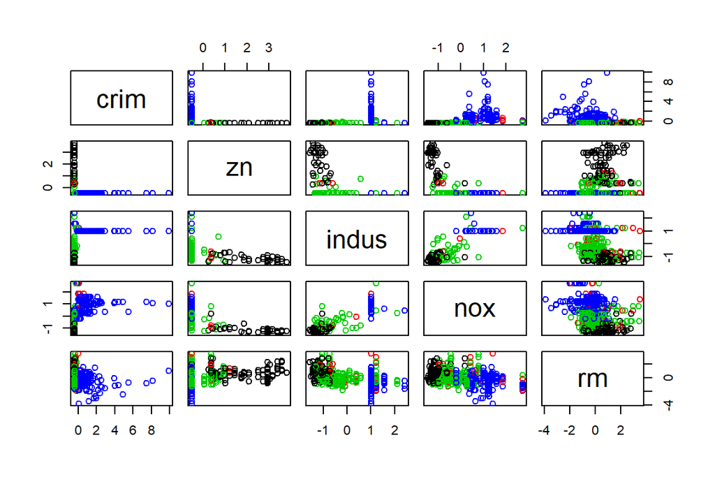

```r
library(MASS)
library(ggplot2)
library(GGally)
library(dplyr)
km <-kmeans(boston, centers = 4)

# plot the Boston dataset with clusters
par(mfrow=c(2,2))
pairs(boston[c(1,2,3,5,6)], col = km$cluster)
```

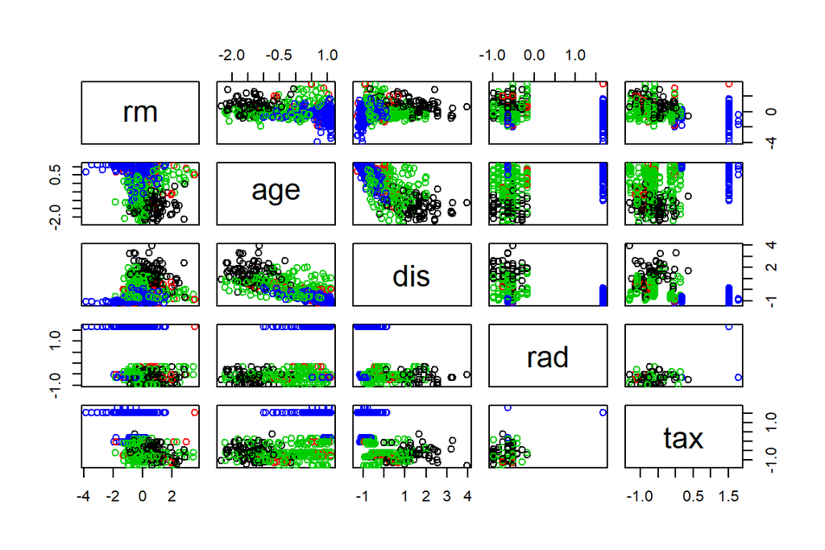

```r
pairs(boston[6:10], col = km$cluster)
```

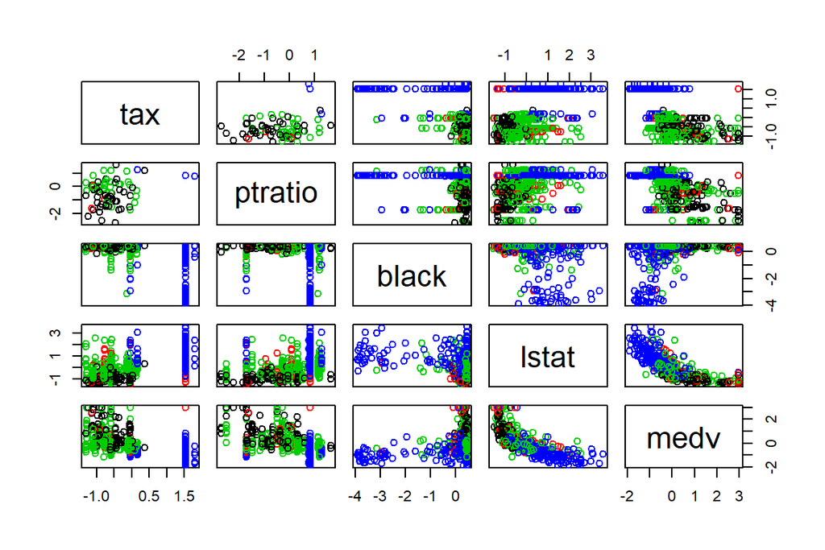

```r
pairs(boston[10:14], col = km$cluster)
```

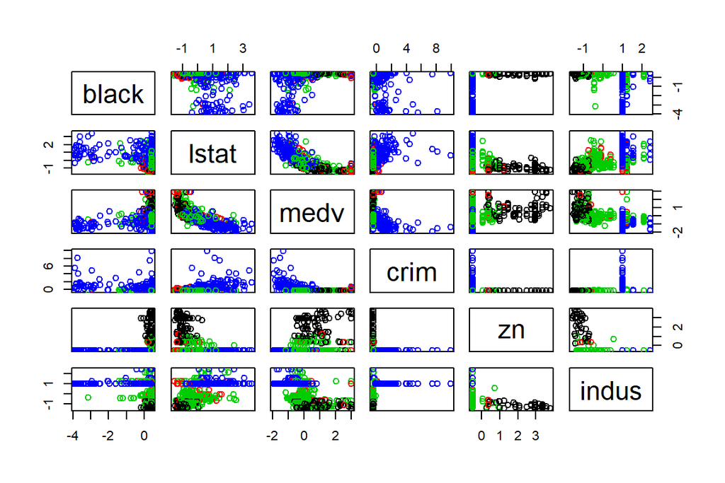

```r
pairs(boston[c(12,13,14,1,2,3)], col = km$cluster)
```

# Week 5 is for fun!

## Data, right?

### No. The *correct* way to address a senior officer is “Lieutnant Data”.

This week we will look into the human dataset from the UN report of 2015. The data looks following:

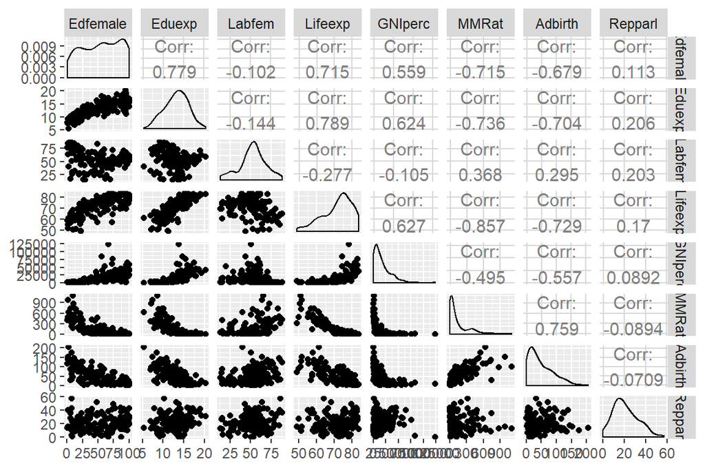

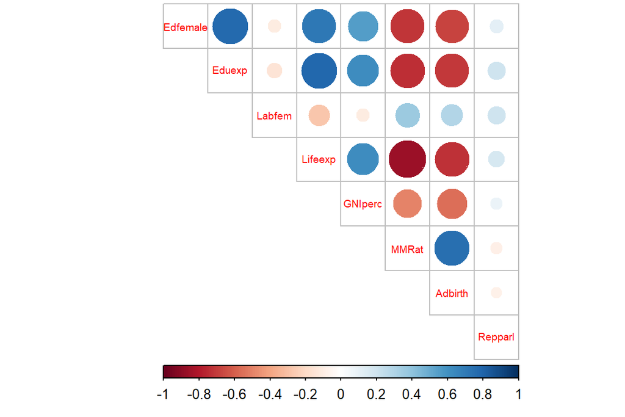

```
##     Edfemale          Eduexp          Labfem         Lifeexp
##  Min.   :  0.90   Min.   : 5.40   Min.   :13.50   Min.   :49.00
##  1st Qu.: 27.15   1st Qu.:11.25   1st Qu.:44.45   1st Qu.:66.30
##  Median : 56.60   Median :13.50   Median :53.50   Median :74.20
##  Mean   : 55.37   Mean   :13.18   Mean   :52.52   Mean   :71.65
##  3rd Qu.: 85.15   3rd Qu.:15.20   3rd Qu.:61.90   3rd Qu.:77.25
##  Max.   :100.00   Max.   :20.20   Max.   :88.10   Max.   :83.50
##     GNIperc           MMRat           Adbirth          Repparl
##  Min.   :   581   Min.   :   1.0   Min.   :  0.60   Min.   : 0.00
##  1st Qu.:  4198   1st Qu.:  11.5   1st Qu.: 12.65   1st Qu.:12.40
##  Median : 12040   Median :  49.0   Median : 33.60   Median :19.30
##  Mean   : 17628   Mean   : 149.1   Mean   : 47.16   Mean   :20.91
##  3rd Qu.: 24512   3rd Qu.: 190.0   3rd Qu.: 71.95   3rd Qu.:27.95
##  Max.   :123124   Max.   :1100.0   Max.   :204.80   Max.   :57.50
```

It seems that the variables are numeric, with some represented as percentages. The ratio of women in the labour force seems not to correllate with the rest of the bunch, while others have high correlations. Specifically, the education of women, education expectancy and life expectancy correlate highly with adolescent birth rate, maternal mortality and GNI per capita. This is to be expected since the more women educate themselves, the later they generally have children and high education rates lead to low mortalities. Life expectancy obviously correllates with maternal mortality and eduexp with edufem, but these seem to be quite obvious correllations to the educated reader.

The other two variables seem to have much lower correllations with the rest of the stuff, but seem quite similar to each other in that respect. Both represent somehow the working status of women.

## 2. PCA or finding the true variables

PCA is used to find the relevant variable combinations in the dataset. Since many of the variables correlate, this seems a prudent approach to reducing the dimensionality of the data.

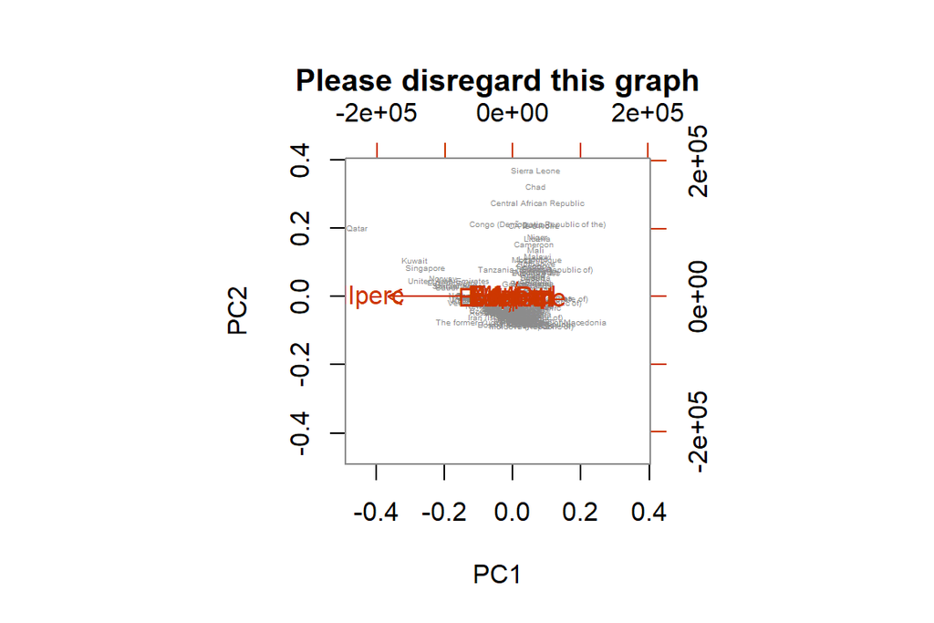

The only principal component the analysis detects is GNI. This seems prudent, since the values of that variable are by FAR greater than most of the other ones. This leads to the analysis running to almost zero components for the rest of the stuff, so let’s just not look at that ever again.

Now we will standardize the data and try it again.

```r
human_std<-scale(Human)
summary(human_std)
```

```
##     Edfemale            Eduexp            Labfem            Lifeexp
##  Min.   :-1.76122   Min.   :-2.7378   Min.   :-2.43186   Min.   :-2.7188
##  1st Qu.:-0.91250   1st Qu.:-0.6782   1st Qu.:-0.50289   1st Qu.:-0.6425
##  Median : 0.03967   Median : 0.1140   Median : 0.06116   Median : 0.3056
##  Mean   : 0.00000   Mean   : 0.0000   Mean   : 0.00000   Mean   : 0.0000
##  3rd Qu.: 0.96275   3rd Qu.: 0.7126   3rd Qu.: 0.58469   3rd Qu.: 0.6717
##  Max.   : 1.44288   Max.   : 2.4730   Max.   : 2.21762   Max.   : 1.4218
##     GNIperc            MMRat            Adbirth           Repparl
##  Min.   :-0.9193   Min.   :-0.6992   Min.   :-1.1325   Min.   :-1.8203
##  1st Qu.:-0.7243   1st Qu.:-0.6496   1st Qu.:-0.8394   1st Qu.:-0.7409
##  Median :-0.3013   Median :-0.4726   Median :-0.3298   Median :-0.1403
##  Mean   : 0.0000   Mean   : 0.0000   Mean   : 0.0000   Mean   : 0.0000
##  3rd Qu.: 0.3712   3rd Qu.: 0.1932   3rd Qu.: 0.6030   3rd Qu.: 0.6127
##  Max.   : 5.6890   Max.   : 4.4899   Max.   : 3.8344   Max.   : 3.1850
```

We see that now the variables are centered with std = 1. Now for some PCA!

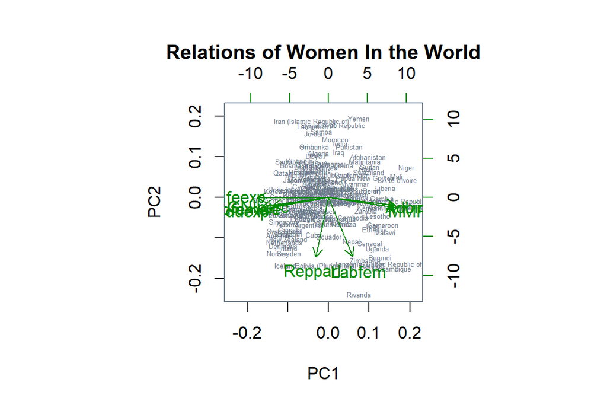

That looks immensely better. The PC1 component seems to correspond to Education rate of women and the GNI of the country. These are highly correllated as we saw in the first plot and it seems prudent that joint component representing all these variables be created. The second component contains the variables for female labour and the ratio of women in parliament. This seems to indicate that both the variables are measuring similar things. One would be tempted to say that the respect for women is among them, but we will refrain from making such quick inferences based on only one analysis.

Looking again at the correlation plot done on the data matrix first, we see that the PCA detects sets of variables related to one another.

# Week 6 is for lazy.

No analysis done. feel free to reprimand on points.